# Lab 1 - Checkpoint 4

Arnaldo Gualberto

04/04/2017

No checkpoint 4 do lab1, eu devo escolher 2 perguntas que fiz no checkpoint 3 e respondê-las utilizando ferramentas visuais e numéricas de análise descritiva e exploratória. Portanto, as duas questões que eu escolhi responder são:

**1. Para o ano de 2015 (ano de eleições), quanto cada partido gasta ao longo dos meses do ano? Será que o valor aumenta à medida que as eleições se aproximam?**

**2. Qual a correlação entre a cota por estado e o valor líquido? Ou seja, será que estados que tem maior cota necessariamente gastam mais?**

# 0. Includes e Settings

```r
library(dplyr, warn.conflicts = F)
library(ggplot2)
library(readr)
library(stringr)
library(knitr)

# Coloca todos os titulos dos gráficos centralizados
theme_update(plot.title = element_text(hjust=0.5))

# vetor para os meses do ano
meses <- c("Janeiro", "Fevereiro", "Março", "Abril", "Maio", "Junho", "Julho", "Agosto", "Setembro", "Outubro", "Novembro", "Dezembro")

# paleta de cores
colorPalette <- c("#000000", "#9D9D9D", "#FFFFFF", "#BE2633", "#E06F8B", "#493C2B", "#A46422", "#EB8931", "#F7E26B", "#2F484E", "#44891A", "#A3CE27", "#1B2632", "#005784", "#31A2F2", "#B2DCEF")
```

# 1. Leitura e limpeza dos dados

Primeiramente, vou carregar os dados e ter uma visão rápida deles:

```r
dados <- read_csv("dados/2015-2016-ate-mes-7.csv")
glimpse(dados)
```

```
## Observations: 523,131
## Variables: 29
## $ sgPartido                 <chr> "DEM", "DEM", "DEM", "DEM", "DEM", "...
## $ numMes                    <int> 1, 3, 2, 3, 2, 3, 2, 4, 5, 2, 2, 2, ...
## $ txtCNPJCPF                <chr> "05939467000115", "05939467000115", ...
## $ vlrGlosa                  <dbl> 6.00, 1.60, 0.00, 9.85, 0.00, 0.00, ...
## $ txNomeParlamentar         <chr> "ABEL MESQUITA JR.", "ABEL MESQUITA ...
## $ sgUF                      <chr> "RR", "RR", "RR", "RR", "RR", "RR", ...
## $ nuCarteiraParlamentar     <int> 1, 1, 1, 1, 1, 1, 1, 1, 1, 1, 1, 1, ...
## $ vlrDocumento              <dbl> 37.37, 38.84, 33.30, 464.32, 112.12,...
## $ nuDeputadoId              <int> 3074, 3074, 3074, 3074, 3074, 3074, ...
## $ numSubCota                <int> 1, 1, 1, 1, 1, 3, 3, 3, 3, 3, 3, 3, ...
## $ txtDescricaoEspecificacao <chr> NA, NA, NA, NA, NA, "Veículos Automo...
## $ datEmissao                <dttm> 2016-02-15, 2016-03-12, 2016-02-15,...
## $ codLegislatura            <int> 55, 55, 55, 55, 55, 55, 55, 55, 55, ...
```

[output cut: 16 more lines]

Uma explicação mais detalhada sobre cada coluna, pode ser encontrada [aqui](http://www2.camara.leg.br/transparencia/cota-para-exercicio-da-atividade-parlamentar/explicacoes-sobre-o-formato-dos-arquivos-xml).

Vou selecionar, então, somente as colunas que me interessam e remover as linhas com *NA*:

```r
dados <- dados %>%
  select(partido = sgPartido,
         nome = txNomeParlamentar,
         estado = sgUF,
         descricao = txtDescricao,
         valor_liq = vlrLiquido,
         mes = numMes,
         ano = numAno) %>%
  filter(complete.cases(.))
kable(head(dados, 10))
```

| partido | nome | estado | descricao | valor_liq | mes | ano |
| --- | --- | --- | --- | --- | --- | --- |
| DEM | ABEL MESQUITA JR. | RR | MANUTENÇÃO DE ESCRITÓRIO DE APOIO À ATIVIDADE PARLAMENTAR | 31.37 | 1 | 2016 |
| DEM | ABEL MESQUITA JR. | RR | MANUTENÇÃO DE ESCRITÓRIO DE APOIO À ATIVIDADE PARLAMENTAR | 37.24 | 3 | 2016 |
| DEM | ABEL MESQUITA JR. | RR | MANUTENÇÃO DE ESCRITÓRIO DE APOIO À ATIVIDADE PARLAMENTAR | 33.30 | 2 | 2016 |
| DEM | ABEL MESQUITA JR. | RR | MANUTENÇÃO DE ESCRITÓRIO DE APOIO À ATIVIDADE PARLAMENTAR | 454.47 | 3 | 2016 |
| DEM | ABEL MESQUITA JR. | RR | MANUTENÇÃO DE ESCRITÓRIO DE APOIO À ATIVIDADE PARLAMENTAR | 112.12 | 2 | 2016 |
| DEM | ABEL MESQUITA JR. | RR | COMBUSTÍVEIS E LUBRIFICANTES. | 4090.96 | 3 | 2016 |
| DEM | ABEL MESQUITA JR. | RR | COMBUSTÍVEIS E LUBRIFICANTES. | 4001.83 | 2 | 2016 |
| DEM | ABEL MESQUITA JR. | RR | COMBUSTÍVEIS E LUBRIFICANTES. | 4280.00 | 4 | 2016 |
| DEM | ABEL MESQUITA JR. | RR | COMBUSTÍVEIS E LUBRIFICANTES. | 4008.50 | 5 | 2016 |
| DEM | ABEL MESQUITA JR. | RR | COMBUSTÍVEIS E LUBRIFICANTES. | 50.00 | 2 | 2016 |

Agora, quero analisar os valores únicos de algumas das colunas que selecionei:

```r
"Partidos:";unique(dados$partido);
```

```
## [1] "Partidos:"
```

```
##  [1] "DEM"     "PP"      "PTB"     "PT"      "PR"      "PTN"     "PSB"
##  [8] "PDT"     "PRB"     "PMDB"    "REDE"    "PPS"     "PSL"     "PCdoB"
## [15] "PSD"     "PSC"     "PV"      "PSDB"    "SD"      "PTdoB"   "PHS"
## [22] "PSOL"    "PEN"     "PROS"    "S.PART." "PRP"     "PMB"     "PRTB"
## [29] "PMN"
```

```r
"Descrições:";unique(dados$descricao);
```

```
## [1] "Descrições:"
```

```
##  [1] "MANUTENÇÃO DE ESCRITÓRIO DE APOIO À ATIVIDADE PARLAMENTAR"
##  [2] "COMBUSTÍVEIS E LUBRIFICANTES."
##  [3] "CONSULTORIAS, PESQUISAS E TRABALHOS TÉCNICOS."
##  [4] "DIVULGAÇÃO DA ATIVIDADE PARLAMENTAR."
##  [5] "SERVIÇO DE SEGURANÇA PRESTADO POR EMPRESA ESPECIALIZADA."
##  [6] "TELEFONIA"
##  [7] "SERVIÇOS POSTAIS"
##  [8] "LOCAÇÃO OU FRETAMENTO DE VEÍCULOS AUTOMOTORES"
##  [9] "Emissão Bilhete Aéreo"
## [10] "PASSAGENS AÉREAS"
## [11] "FORNECIMENTO DE ALIMENTAÇÃO DO PARLAMENTAR"
## [12] "SERVIÇO DE TÁXI, PEDÁGIO E ESTACIONAMENTO"
## [13] "ASSINATURA DE PUBLICAÇÕES"
## [14] "HOSPEDAGEM ,EXCETO DO PARLAMENTAR NO DISTRITO FEDERAL."
## [15] "PASSAGENS TERRESTRES, MARÍTIMAS OU FLUVIAIS"
## [16] "LOCAÇÃO OU FRETAMENTO DE AERONAVES"
## [17] "LOCAÇÃO OU FRETAMENTO DE EMBARCAÇÕES"
## [18] "PARTICIPAÇÃO EM CURSO, PALESTRA OU EVENTO SIMILAR"
```

Podemos ver que, ao todo, temos 29 partidos e 18 tipos de despesas diferentes. A partir dos dados que vi até aqui, vou efetuar as seguintes transformações:

1. Converter os nomes dos deputados e as descrições de despesas para *CamelCase*;
2. Converter as despesas *Emissão de Bilhete Aéreo* para *PASSAGENS AÉREAS*, já que representam a mesma coisa.
3. Remover os valores líquidos negativos para não atrapalhar nos cálculos sobre os valores.

```r
dados <- dados %>%
  mutate(descricao = ifelse(descricao == "Emissão Bilhete Aéreo", "PASSAGENS AÉREAS", descricao)) %>%
  mutate(nome = str_to_title(nome)) %>%
  mutate(descricao = str_to_title(descricao)) %>%
  filter(valor_liq > 0)
```

# 2. Respostas

#### a. Para o ano de 2015 (ano de eleições), quanto cada partido gasta ao longo dos meses do ano?

Primeiramente, tenho de filtrar os dados somente de 2015.

```r
dados_2015 = dados %>%
  filter(ano == 2015)

dados_2015 %>%
  head() %>%
  kable()
```

| partido | nome | estado | descricao | valor_liq | mes | ano |
| --- | --- | --- | --- | --- | --- | --- |
| DEM | Abel Mesquita Jr. | RR | Manutenção De Escritório De Apoio À Atividade Parlamentar | 165.65 | 11 | 2015 |
| DEM | Abel Mesquita Jr. | RR | Manutenção De Escritório De Apoio À Atividade Parlamentar | 59.48 | 12 | 2015 |
| DEM | Abel Mesquita Jr. | RR | Manutenção De Escritório De Apoio À Atividade Parlamentar | 130.95 | 11 | 2015 |
| DEM | Abel Mesquita Jr. | RR | Manutenção De Escritório De Apoio À Atividade Parlamentar | 193.06 | 12 | 2015 |
| DEM | Abel Mesquita Jr. | RR | Manutenção De Escritório De Apoio À Atividade Parlamentar | 310.25 | 2 | 2015 |
| DEM | Abel Mesquita Jr. | RR | Combustíveis E Lubrificantes. | 32.00 | 6 | 2015 |

Além disso, vou restringir minhas análises aos 10 partidos que mais gastaram ao longo do ano, pois quero facilitar a visualização dos gráficos.

```r
# Sumariza os gastos totais dos 10 partidos que mais gastam
dados_sum_top_10 = dados_2015 %>%
  group_by(partido) %>%
  summarise(total = sum(valor_liq)) %>%
  top_n(10, total)

# Pega os dados somentes dos 10 partidos que mais gastam
dados_2015 <- dados_2015 %>%
  filter(partido %in% dados_sum_top_10$partido)
```

Antes de responder a pergunta, quero analisar o valor total gasto pelos 10 partidos que mais gastaram no ano de 2015:

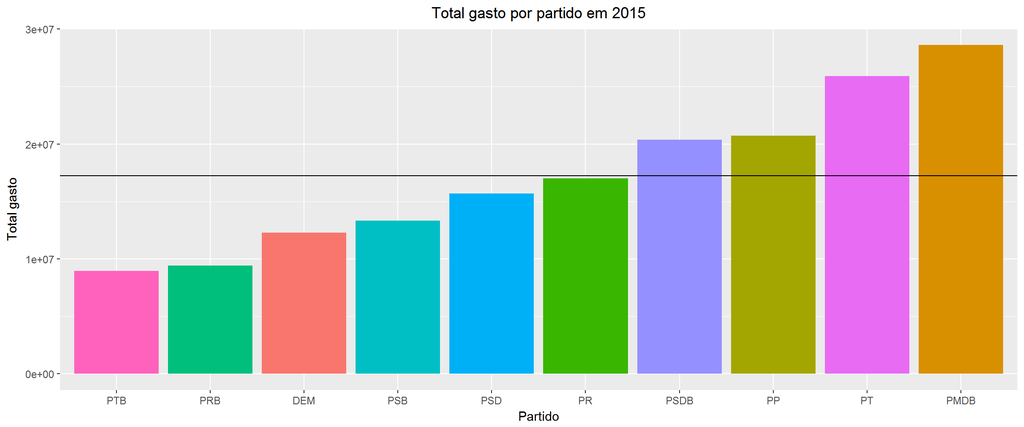

```r
dados_sum_top_10 %>%
  ggplot(aes(x=reorder(partido, total), y = total, fill=partido)) +
  geom_bar(stat="identity") +
  geom_hline(yintercept = mean(dados_sum_top_10$total)) +
  labs(x = "Partido", y = "Total gasto") +
  ggtitle("Total gasto por partido em 2015") +
  theme(legend.position = "none")
```

Pelo gráfico acima, pode-ser perceber que **o PMDB foi o partido que mais gastou em 2015, seguido pelo PT, PP e PSDB.** Esses 4 partidos, aliás, gastam mais que a média dos 10 partidos que mais gastaram (aproximadamente 17 milhões de reais).

Quero agora observar a distribuição dos valores gastos por cada um desses partidos, além de ter uma noção geral desses valores:

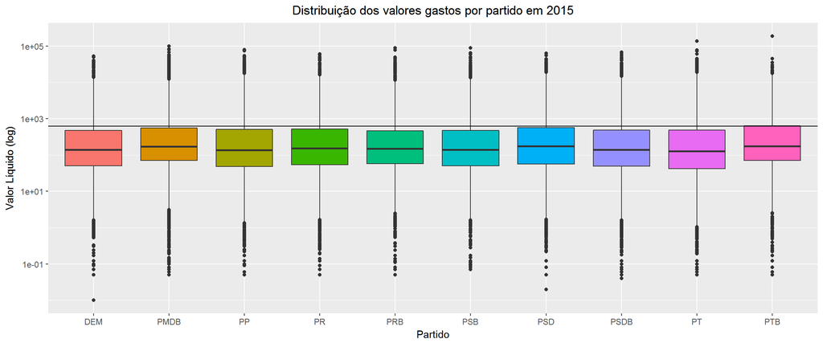

```r
dados_2015 %>%
  group_by(partido) %>%
  ggplot(aes(x = partido, y = valor_liq, fill = partido)) +
  geom_boxplot() +
  geom_hline(yintercept = mean(dados_2015$valor_liq)) +
  scale_y_log10() +
  labs(x = "Partido", y = "Valor Líquido (log)") +
  ggtitle("Distribuição dos valores gastos por partido em 2015") +
  theme(legend.position = "none")
```

```r
summary(dados_2015$valor_liq)
```

```
##      Min.   1st Qu.    Median      Mean   3rd Qu.      Max.
##      0.01     50.00    150.00    625.00    509.90 189600.00
```

```r
dados_2015 %>%
  group_by(partido) %>%
  summarise(min = min(valor_liq), mean=mean(valor_liq), median=median(valor_liq), iqr=IQR(valor_liq), max=max(valor_liq)) %>%
  kable()
```

| partido | min | mean | median | iqr | max |
| --- | --- | --- | --- | --- | --- |
| DEM | 0.01 | 644.2103 | 138.500 | 422.610 | 53000 |
| PMDB | 0.05 | 643.5721 | 170.330 | 481.310 | 99900 |
| PP | 0.05 | 606.9287 | 135.000 | 461.400 | 79000 |
| PR | 0.05 | 666.0651 | 152.420 | 470.640 | 60750 |
| PRB | 0.05 | 765.2683 | 148.905 | 409.665 | 88500 |
| PSB | 0.07 | 590.9390 | 140.020 | 421.465 | 89000 |
| PSD | 0.02 | 723.3072 | 174.005 | 516.630 | 63750 |
| PSDB | 0.04 | 544.1179 | 140.050 | 431.270 | 68400 |
| PT | 0.05 | 554.3543 | 128.000 | 443.010 | 137900 |
| PTB | 0.05 | 762.5461 | 175.250 | 571.410 | 189600 |

Pode-se perceber que os partidos apresentam uma distância interquartil (tamanho da caixa) e mediana bem similar. Além disso, em praticamente todos os partidos, 75% dos valores encontram-se abaixo da média.

Agora, para responder a pergunta, vou mostrar o gráfico do valor líquido gasto por partido ao longo do ano de 2015:

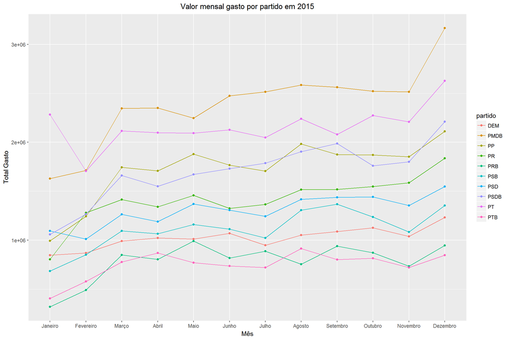

```r
dados_sum <- dados_2015 %>%
  group_by(partido, mes) %>%
  summarise(total = sum(valor_liq))

dados_sum %>%
  ggplot(aes(x = mes, y = total, fill=partido)) +
  geom_line(aes(colour = partido)) +
  geom_point(aes(color=partido)) +
  xlim(meses) +
  labs(x = "Mês", y = "Total Gasto") +
  ggtitle("Valor mensal gasto por partido em 2015")
```

O gráfico acima também pode ser visualizado de maneira separada para cada partido:

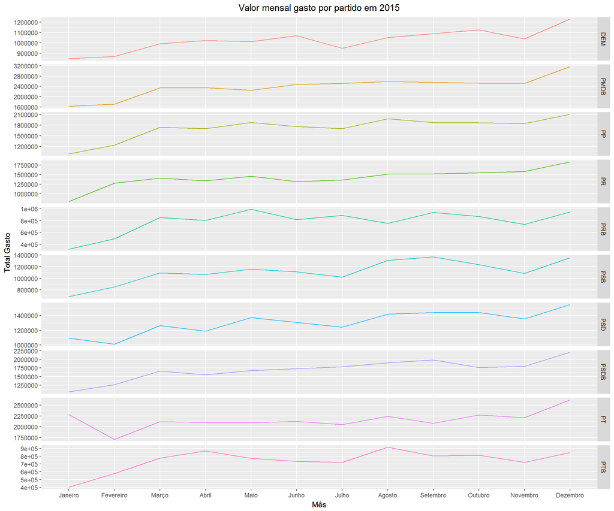

```r
dados_sum <- dados_2015 %>%
  group_by(partido, mes) %>%
  summarise(total = sum(valor_liq))

dados_sum %>%
  ggplot(aes(x = mes, y = total, fill=partido)) +
  geom_line(aes(colour = partido)) +
  facet_grid(partido ~ ., scale="free") +
  xlim(meses) +
  labs(x = "Mês", y = "Total Gasto") +
  theme(legend.position = "none") +
  ggtitle("Valor mensal gasto por partido em 2015")
```

De uma maneira geral, **os valores gastos por partido tendem a aumentar ao longo do ano**, como esperado. Porém, ao contrário do imaginado, **não há um aumento de gastos significante perto das eleições** (meses anteriores a Outubro). Além disso, o gráfico mostra dois pontos que eu considero importante: **todos os partidos aumentaram os gastos entre os meses Fevereiro-Março e Novembro-Dezembro.**

Como minha pergunta extra a essa questão, quero analisar então os gastos dos meses de Março e Dezembro.

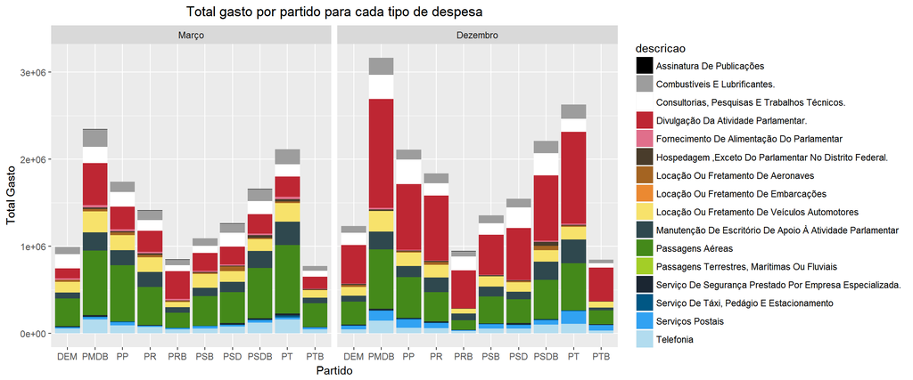

```r
dados_sum <- dados_2015 %>%
  group_by(partido, mes, descricao) %>%
  filter(mes == 3 || mes == 12) %>%
  summarise(total = sum(valor_liq))

dados_sum %>%
  ggplot(aes(x = partido, y = total, fill = descricao)) +
  geom_bar(position = "stack", stat = "identity") +
  facet_wrap(~ mes, labeller = as_labeller(c("3" = "Março", "12" = "Dezembro"))) +
  scale_fill_manual(values = colorPalette) +
  labs(x = "Partido", y = "Total Gasto") +
  ggtitle("Total gasto por partido para cada tipo de despesa")
```

Também podemos, visualizar o gráfico acima de forma proporcional:

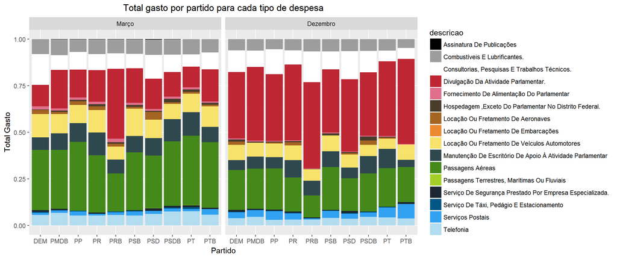

```r
dados_sum %>%
  ggplot(aes(x = partido, y = total, fill = descricao)) +
  geom_bar(position = "fill", stat = "identity") +
  facet_wrap(~ mes, labeller = as_labeller(c("3" = "Março", "12" = "Dezembro"))) +
  scale_fill_manual(values = colorPalette) +
  labs(x = "Partido", y = "Total Gasto") +
  ggtitle("Total gasto por partido para cada tipo de despesa")
```

Pelos gráficos acima, pode-se observar que, comparando-se os meses de Março e Dezembro:

- houve um aumento significativo nas despesas com *Divulgação da Atividade Parlamentar*;
- diminuiram-se as despesas com *Passagens Aéreas* e, de certa forma, *Locação Ou Fretamento de Veículos Automores*;

#### b. Qual a correlação entre a cota por estado e o valor líquido? Ou seja, será que estados que tem maior cota necessariamente gastam mais?

Antes de mais nada, será necessário carregar o arquivo com as informações sobre a cota por estado:

```r
dados_cota = read_csv2("dados/valor-cota-por-estado.csv") %>% rename(cota = valor)
```

```
## Using ',' as decimal and '.' as grouping mark. Use read_delim() for more control.
```

```r
head(dados_cota) %>% kable()
```

| estado | cota |
| --- | --- |
| AC | 44632.46 |
| AL | 40944.10 |
| AM | 43570.12 |
| AP | 43374.78 |
| BA | 39010.85 |
| CE | 42451.77 |

Também será necessário recarregar os dados de 2015 (para incluir os gastos de todos os partidos):

```r
dados_2015 = dados %>%
  filter(ano == 2015)
```

Também vou criar um dataframe que conterá as principais informações para as respostas, me ajudando a respondê-las:

```r
# numero de deputados por estado
dados_dep_por_estado <- dados_2015 %>%
  group_by(estado) %>%
  summarise(n_deputados = length(unique(nome)))

# valor total gasto por estado no ano de 2015
dados_gastos_por_estado <- dados_2015 %>%
  group_by(estado) %>%
  summarise(total_anual_gasto = sum(valor_liq))

# valor total de cotas e gasto por estado
dados_join <- left_join(dados_dep_por_estado, dados_cota, by = "estado") %>%
  mutate(total_anual_cotas = n_deputados*cota*12) %>%
  left_join(dados_gastos_por_estado, by = "estado")

head(dados_join) %>% kable()
```

| estado | n_deputados | cota | total_anual_cotas | total_anual_gasto |
| --- | --- | --- | --- | --- |
| AC | 14 | 44632.46 | 7498253 | 3804760 |
| AL | 15 | 40944.10 | 7369938 | 3979707 |
| AM | 15 | 43570.12 | 7842622 | 3557007 |
| AP | 14 | 43374.78 | 7286963 | 3924560 |
| BA | 57 | 39010.85 | 26683421 | 17222320 |
| CE | 33 | 42451.77 | 16810901 | 10416652 |

Vou começar com a análise descritivas das variáveis utilizadas - assim como na pergunta anterior - visualizando a distribuição das cotas:

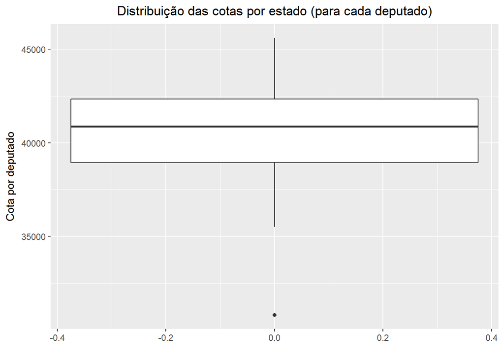

```r
dados_cota %>%
  ggplot(aes(x= 0, y = cota)) +
  geom_boxplot() +
  labs(x = "", y = "Cota por deputado") +
  ggtitle("Distribuição das cotas por estado (para cada deputado)")
```

```r
summary(dados_cota$cota)
```

```
##    Min. 1st Qu.  Median    Mean 3rd Qu.    Max.
##   30790   38940   40880   40260   42340   45610
```

Pode-se ver que os deputados recebem entre R$30.790,00 e R$45.610,00. Além disso, a cota média (R$40.260,00) é próxima da mediana (R$40.880,00).

Agora, estou curioso para saber a cota que cada deputado tem dependendo do estado:

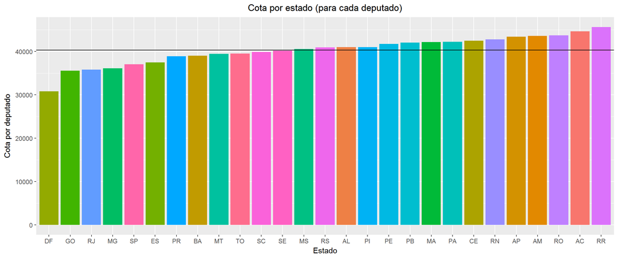

```r
dados_cota %>%
  ggplot(aes(x=reorder(estado, cota), y=cota, fill=estado)) +
  geom_bar(stat = "identity") +
  geom_hline(yintercept = mean(dados_cota$cota)) +
  labs(x = "Estado", y = "Cota por deputado") +
  theme(legend.position = "none") +
  ggtitle("Cota por estado (para cada deputado)")
```

Podemos ver que **o estado de RR é o estado com a maior cota para deputado, enquanto o DF é o estado com a menor cota.**

Também quero saber a quantidade de deputados por estado:

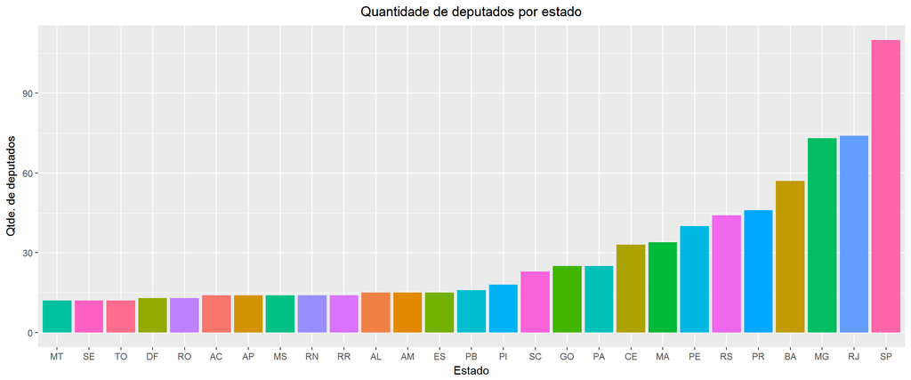

```r
dados_dep_por_estado %>%
  ggplot(aes(x = reorder(estado, n_deputados), y = n_deputados, fill=estado)) +
  geom_bar(stat = "identity") +
  labs(x = "Estado", y= "Qtde. de deputados") +
  theme(legend.position = "none") +
  ggtitle("Quantidade de deputados por estado")
```

Para finalizar as análises das variáveis, quero visualizar o valor total gasto por estado:

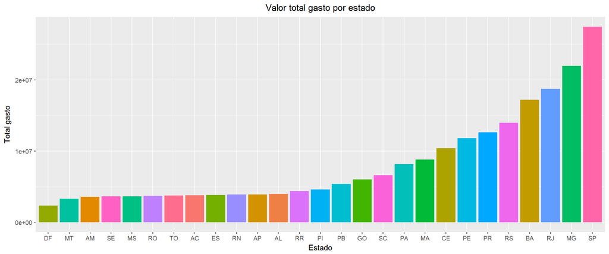

```r
dados_gastos_por_estado %>%
  ggplot(aes(x = reorder(estado, total_anual_gasto), y = total_anual_gasto, fill=estado)) +
  geom_bar(stat = "identity") +
  labs(x = "Estado", y = "Total gasto") +
  theme(legend.position = "none") +
  ggtitle("Valor total gasto por estado")
```

Percebe-se que o gráfico acima apresenta uma tendência bem parecida com a do gráfico anterior, inclusive com os estados em posições próximas do ranking. Isso pode ser um indício que quanto maior o número de deputados em um estado, maior o valor total gasto pelo estado, o que é de se esperar.

Agora, para responder a pergunta do exercício, vou analisar a relação entre a cota que o estado recebe e o valor líquido total gasto anual. Eu espero que haja uma forte correlação entre essas variáveis (acima de 0.7 para o coeficiente de Pearson):

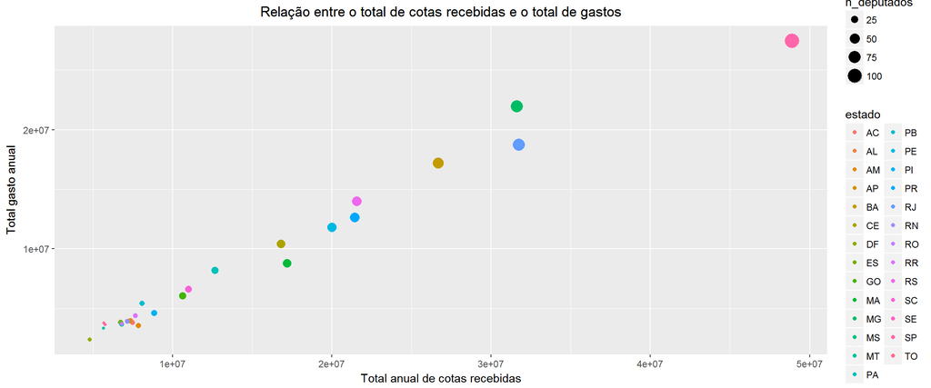

```r
dados_join %>%
  ggplot(aes(x = total_anual_cotas, y = total_anual_gasto)) +
  geom_point(aes(colour=estado, size=n_deputados)) +
  labs(x = "Total anual de cotas recebidas", y = "Total gasto anual") +
  ggtitle("Relação entre o total de cotas recebidas e o total de gastos")
```

O gráfico nos mostra que **há uma relação entre o total de cotas que o estado recebe e o valor total gasto anualmente**, conforme o esperado. Em outras palavras, **estados que recebem um maior valor de cota (quando somados todos os deputados), gastam mais ao longo do ano que os estados que recebem menos cotas.** O gráfico também mostra, pelo tamanho dos círculos, que essa correlação é influenciada pelo número de deputados, onde estados com mais deputados gastam mais. Além disso, também é possível observar que o estado de São Paulo (ponto mais superior-direito) se destaca em relação aos outros estados, mas segue a mesma tendência de gastos.

Para verificar a correlação das variáveis, vou analisar os coeficientes de correlação:

```r
cor(dados_join$total_anual_cotas, dados_join$total_anual_gasto, method='pearson')
```

```
## [1] 0.990331
```

```r
cor(dados_join$total_anual_cotas, dados_join$total_anual_gasto, method='kendall')
```

```
## [1] 0.8746439
```

```r
cor(dados_join$total_anual_cotas, dados_join$total_anual_gasto, method='spearman')
```

```
## [1] 0.9505495
```

Logo, **os coeficientes também confirmam uma forte relação positiva entre a cota anual recebida por estado e o valor líquido total gasto anualmente.**

A título de curiosidade, resolvi plotar o mesmo gráfico novamente, porém comparando o valor total gasto anual pelo número de deputados de um estado:

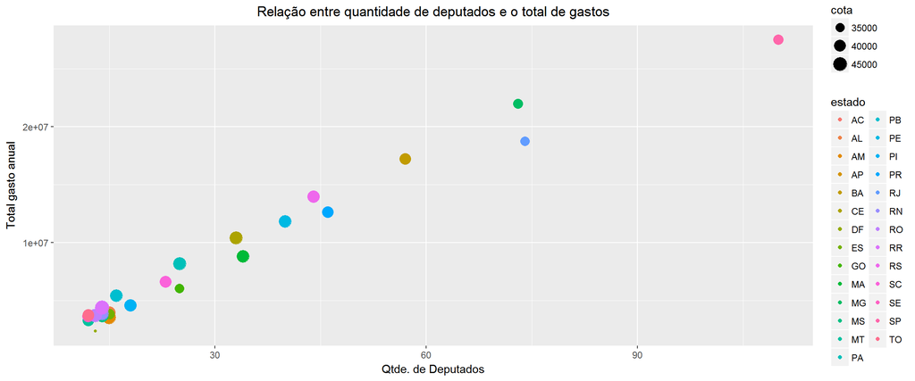

```r
dados_join %>%
  ggplot(aes(x = n_deputados, y = total_anual_gasto)) +
  geom_point(aes(colour = estado, size=cota)) +
  labs(x = "Qtde. de Deputados", y = "Total gasto anual") +
  ggtitle("Relação entre quantidade de deputados e o total de gastos")
```

O gráfico, como esperado, apresenta um comportamento similar ao anterior, porém agora podemos ver que **o valor da cota recebido por deputado (tamanho do círculo) não influencia necessariamente no valor total gasto anual**. Alguns estados que recebem cotas maiores (círculos maiores) se concentram na parte inferior-esquerda do gráfico. Obviamente, isso deve-se ao fato (provavelmente) de serem estados com menos deputados.

Também quis observar a correlação entre a quantidade de deputados e o total gasto anual:

```r
cor(dados_join$n_deputados, dados_join$total_anual_gasto, method='pearson')
```

```
## [1] 0.9877114
```

```r
cor(dados_join$n_deputados, dados_join$total_anual_gasto, method='kendall')
```

```
## [1] 0.839472
```

```r
cor(dados_join$n_deputados, dados_join$total_anual_gasto, method='spearman')
```

```
## [1] 0.9411323
```

Os coeficientes acima são bem similares aos coeficientes da correlação analisada anteriormente (total de cotas recebidas anualmente por estado x total anual gasto).

Por fim, como questão extra, resolvi analisar a relação entre a cota recebida e o gasto médio mensal por deputado de cada estado:

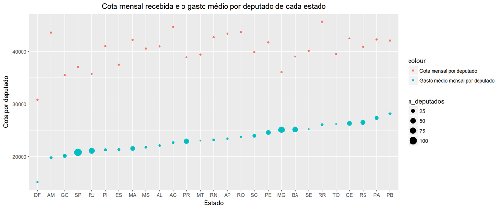

```r
dados_join %>%
  mutate(cota = total_anual_gasto / (n_deputados*12)) %>%
  ggplot(aes(x = reorder(estado, cota), y = cota)) +
  geom_point(aes(colour = "Gasto médio mensal por deputado", size=n_deputados)) +
  geom_point(data = dados_cota, aes(colour="Cota mensal por deputado ")) +
  labs(x = "Estado", y = "Cota por deputado") +
  ggtitle("Cota mensal recebida e o gasto médio por deputado de cada estado")
```

O gráfico acima mostra que **o gasto médio por deputado de cada estado é sempre menor que a cota recebida** (ainda bem!). De fato, de acordo com o gráfico acima, **poderíamos reduzir a cota mensal de cada deputado para R$35.000,00 (até menos) que atenderia perfeitamente a necessidade de todos os estados**. Também podemos observar que **os deputados da Paraíba apresentam o maior gasto médio mensal em comparação com os outros estados, enquanto que cada deputado do DF gasta, em média, aproximadamente metade da cota recebida.**

# 3. Conclusões

Este relatório analisou os dados dos deputados de todos os estados brasileiros no ano de 2015 (ano de eleição). De acordo com as análises, pode-se concluir:

- Os valores gastos por partido tendem a aumentar ao longo do ano, porém não há um aumento de gastos significante nos meses anteriores as eleições;
- Há uma relação entre o total de cotas que o estado recebe e o valor total gasto anualmente. Ou seja, estados que recebem um maior valor de cota (quando somados todos os deputados), gastam mais ao longo do ano que os estados que recebem menos cotas;
- O gasto médio por deputado de cada estado é sempre menor que a cota recebida; e
- Os deputados da Paraíba apresentam o maior gasto médio mensal em comparação com os outros estados.